# R Notebook

```r
library(tidyverse)
library(infer)
library(skimr)
data(msleep)
```

## 1.1 Hypothesis testing - practical

**Question 1.**

Explore the dataset and familiarise yourself with it.

```r
skim(msleep)
```

Data summary

| Name | msleep |
| --- | --- |
| Number of rows | 83 |
| Number of columns | 11 |
| _______________________ |  |
| Column type frequency: |  |
| character | 5 |
| numeric | 6 |
| ________________________ |  |
| Group variables | None |

**Variable type: character**

| skim_variable | n_missing | complete_rate | min | max | empty | n_unique | whitespace |
| --- | --- | --- | --- | --- | --- | --- | --- |
| name | 0 | 1.00 | 3 | 30 | 0 | 83 | 0 |
| genus | 0 | 1.00 | 3 | 13 | 0 | 77 | 0 |
| vore | 7 | 0.92 | 4 | 7 | 0 | 4 | 0 |
| order | 0 | 1.00 | 6 | 15 | 0 | 19 | 0 |
| conservation | 29 | 0.65 | 2 | 12 | 0 | 6 | 0 |

**Variable type: numeric**

| skim_variable | n_missing | complete_rate | mean | sd | p0 | p25 | p50 | p75 | p100 | hist |
| --- | --- | --- | --- | --- | --- | --- | --- | --- | --- | --- |
| sleep_total | 0 | 1.00 | 10.43 | 4.45 | 1.90 | 7.85 | 10.10 | 13.75 | 19.90 | ▅▅▇▆▂ |
| sleep_rem | 22 | 0.73 | 1.88 | 1.30 | 0.10 | 0.90 | 1.50 | 2.40 | 6.60 | ▇▆▂▁▁ |
| sleep_cycle | 51 | 0.39 | 0.44 | 0.36 | 0.12 | 0.18 | 0.33 | 0.58 | 1.50 | ▇▂▁▁▁ |
| awake | 0 | 1.00 | 13.57 | 4.45 | 4.10 | 10.25 | 13.90 | 16.15 | 22.10 | ▂▅▇▃▅ |
| brainwt | 27 | 0.67 | 0.28 | 0.98 | 0.00 | 0.00 | 0.01 | 0.13 | 5.71 | ▇▁▁▁▁ |
| bodywt | 0 | 1.00 | 166.14 | 786.84 | 0.00 | 0.17 | 1.67 | 41.75 | 6654.00 | ▇▁▁▁▁ |

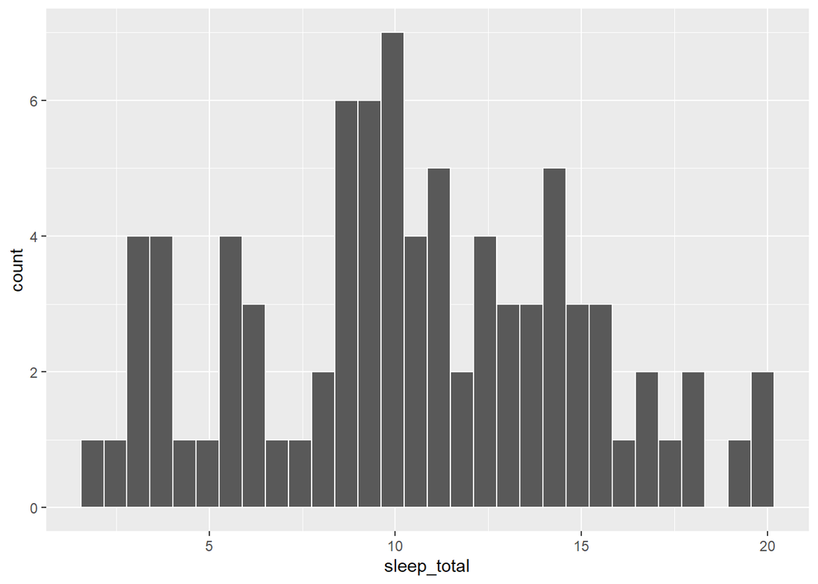

```r
msleep %>%
  ggplot(aes(x = sleep_total))+
  geom_histogram(colour = "white")
```

**Question 2.**

Jabberwockies sleep for around 7 hours a night, on average. Perform an appropriate statistical test to determine whether the mean sleep_total in the sampled population of animal types differs from the typical value for jabberwockies.

Using one sample test.

**H0:** Animals from the data set sleep on average the same amount of time as jabberwockies. (mean_total_sleep == 7)

**H1:** Animals from the data set on average don’t sleep the same amount of time as jabberwockies . (mean_total_sleep != 7)

*α = 0.05*

```r
null_distribution<- msleep %>%
  specify(response = sleep_total) %>%
  hypothesise(null = "point", mu = 7) %>%
  generate(reps = 5000, type = "bootstrap") %>%
  calculate(stat = "mean")

null_distribution
```

| replicate | stat |
| --- | --- |
| 1 | 6.913253 |
| 2 | 6.974699 |
| 3 | 6.693976 |
| 4 | 7.526506 |
| 5 | 6.887952 |
| 6 | 6.849398 |
| 7 | 7.242169 |
| 8 | 6.913253 |
| 9 | 7.840964 |
| 10 | 6.791566 |

[output cut: 4990 more lines]

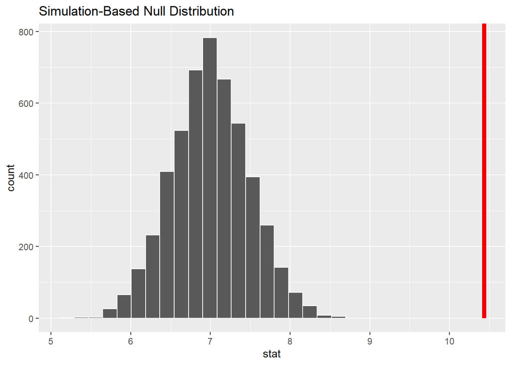

```r
# observed_stats <-
#   msleep %>% summarise(mean_sleep = mean(sleep_total))

observed_stats <- msleep %>% specify(response = sleep_total) %>%
  calculate(stat = "mean")

p_value <- null_distribution %>%
  get_p_value(obs_stat = observed_stats, direction = "both")
null_distribution %>%
  visualise(bins = 20) +
  shade_p_value(obs_stat = observed_stats, direction = "right")
```

**Question 3.**

Perform an appropriate statistical test to determine whether omnivores sleep for significantly longer than herbivores, on average.

Using two sample test - independent

*α = 0.05*

**H0:** The mean sleep duration of omnivores is equal or less to the mean sleep duration of herbivores.

µomni <= µherbi

**H1:** The mean sleep duration of omnivores is greater than herbivores.

µomni > µherb

```r
# narrowing down data to herbivores and omnivores only

herbi_omni <- msleep %>%
  filter(vore == "herbi" | vore == "omni")
  herbi_omni %>%
    group_by(vore) %>%
    summarise(n = n())
```

| vore | n |
| --- | --- |
| herbi | 32 |
| omni | 20 |

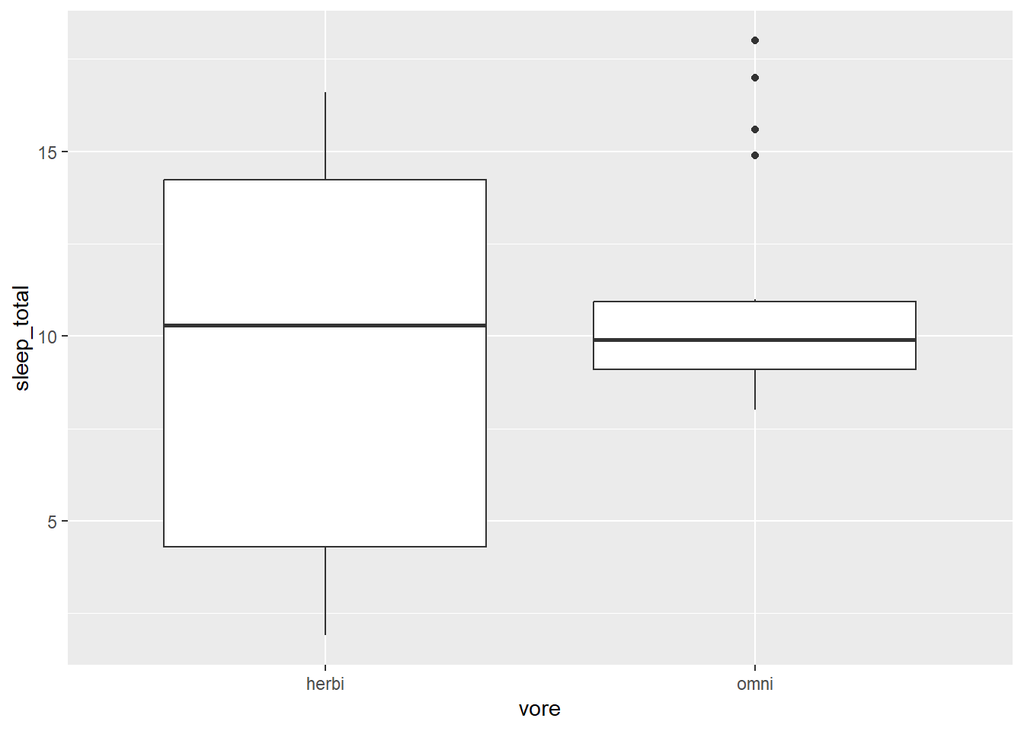

```r
# have a look at the data

  herbi_omni %>%
    ggplot(aes(x = vore, y = sleep_total))+
    geom_boxplot()
```

```r
# create a null-distribution
null_distribution <- herbi_omni %>%
  specify(sleep_total ~ vore) %>%
  hypothesise(null = "independence") %>%
  generate(reps = 1000, type = "permute") %>%
  calculate(stat = "diff in means", order = c("omni", "herbi"))

# create observed_stats
  observed_stats <- herbi_omni %>%
    # summarise(mean_herbi = mean(vore == "herbi"),mean_omni = mean(vore == "omni")) %>%
    # summarise(mean = mean_herbi - mean_omni)
    specify(sleep_total ~ vore) %>%
    calculate(stat = "diff in means", order = c("omni", "herbi"))

  # let's visualise it

  null_distribution %>%
    visualise(bins = 30)+
    shade_p_value (obs_stat = observed_stats, direction = "right")
```

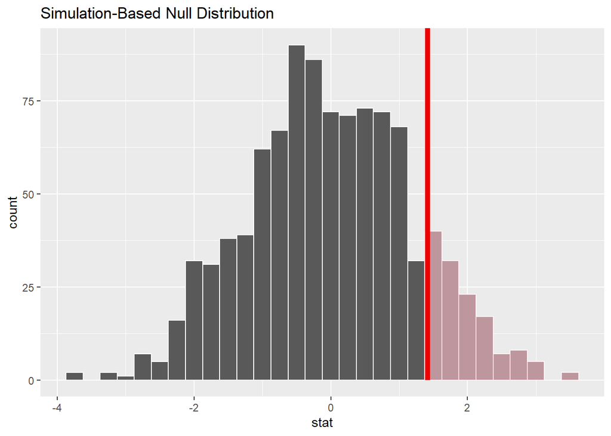

```r
  # let's calculate p-value

 p_value <- null_distribution %>%
   get_p_value(obs_stat = observed_stats, direction = "right")
```

Answer: Since p-value is greater than the significance level of 0.05 , we fail to reject H0. There is not enough evidence to say that the mean sleep duration of omnoivores is greater than the mean duartion of sleep herbivores.

**Question 4.**

Perform an appropriate statistical test to determine whether the proportion of domesticated animal types in the population of animal types is greater than 5%.

one sample - proportions

*α = 0.05*

**H0:** Population of domesticated animals is less or equals to 5% of the whole population of animals. (is_domesticated <= 0.05)

**H1:** Population of domesticated animals is greater than 5% of the whole population of animals. (is_domesticated > 0.05)

Hint Think about creating an is_domesticated variable for the analysis

```r
domesticated <- msleep %>% mutate(is_domesticated = ifelse(conservation == "domesticated", "Yes", "No"),
                                  is_domesticated = ifelse(is.na(is_domesticated), "No", is_domesticated))


domesticated
```

| name | genus | vore | order | conservation | sleep_total | sleep_rem | sleep_cycle | awake | brainwt | bodywt | is_domesticated |
| --- | --- | --- | --- | --- | --- | --- | --- | --- | --- | --- | --- |
| Cheetah | Acinonyx | carni | Carnivora | lc | 12.1 | NA | NA | 11.90 | NA | 50.000 | No |
| Owl monkey | Aotus | omni | Primates | NA | 17.0 | 1.8 | NA | 7.00 | 0.01550 | 0.480 | No |
| Mountain beaver | Aplodontia | herbi | Rodentia | nt | 14.4 | 2.4 | NA | 9.60 | NA | 1.350 | No |
| Greater short-tailed shrew | Blarina | omni | Soricomorpha | lc | 14.9 | 2.3 | 0.1333333 | 9.10 | 0.00029 | 0.019 | No |
| Cow | Bos | herbi | Artiodactyla | domesticated | 4.0 | 0.7 | 0.6666667 | 20.00 | 0.42300 | 600.000 | Yes |
| Three-toed sloth | Bradypus | herbi | Pilosa | NA | 14.4 | 2.2 | 0.7666667 | 9.60 | NA | 3.850 | No |
| Northern fur seal | Callorhinus | carni | Carnivora | vu | 8.7 | 1.4 | 0.3833333 | 15.30 | NA | 20.490 | No |
| Vesper mouse | Calomys | NA | Rodentia | NA | 7.0 | NA | NA | 17.00 | NA | 0.045 | No |
| Dog | Canis | carni | Carnivora | domesticated | 10.1 | 2.9 | 0.3333333 | 13.90 | 0.07000 | 14.000 | Yes |
| Roe deer | Capreolus | herbi | Artiodactyla | lc | 3.0 | NA | NA | 21.00 | 0.09820 | 14.800 | No |

[output cut: 73 more lines]

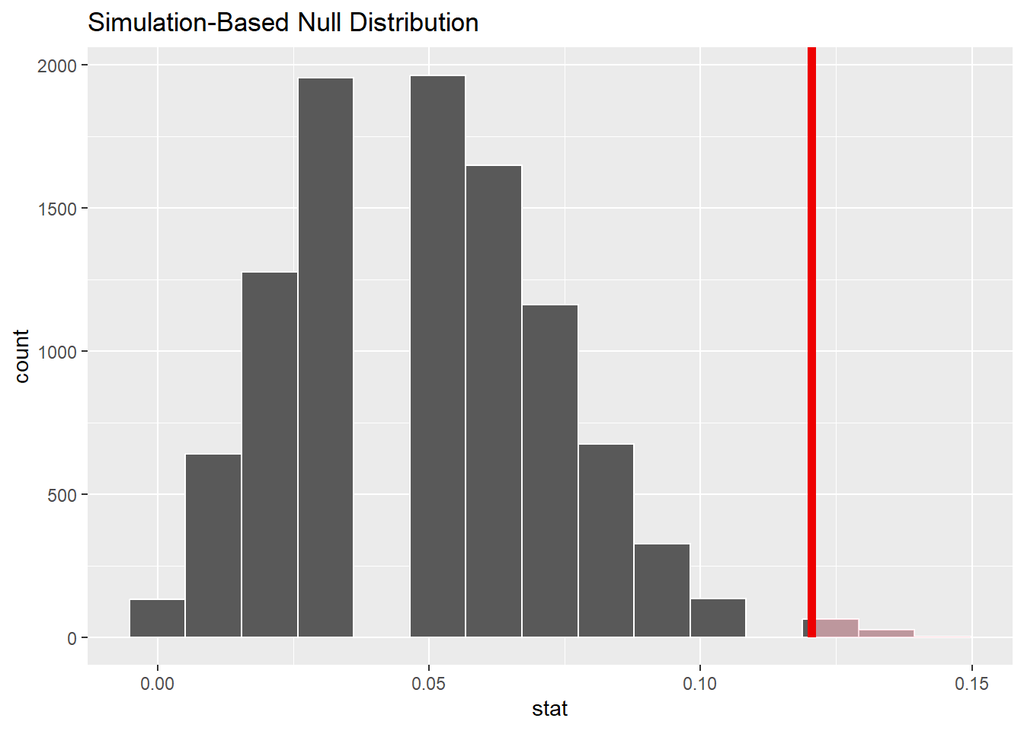

```r
null_distribution <- domesticated %>%
  specify(response = is_domesticated, success = "Yes") %>%
  hypothesise(null = "point", p = 0.05) %>%
  generate(reps = 10000, type = "draw") %>%
  calculate(stat = "prop")

observed_stats <- domesticated %>%
  specify(response = is_domesticated, success = "Yes") %>%
  calculate(stat = "prop")

null_distribution %>%
  visualise()+
  shade_p_value(obs_stat = observed_stats, direction = "right")
```

```r
# calculate p-value

p_value <- null_distribution %>%
  get_p_value(obs_stat = observed_stats, direction = "right")

 p_value
```

| p_value |
| --- |
| 0.009 |

### 1.2 Defining the Hypothesis

For the following three business problems write out:

- What kind of test you would use
- H0 and Ha in both mathematical notation and in words.
- Also state the method you would use to generate the null distribution (bootstrap, permutation or draw).

**Question 1.**

You work for a independent coffee shop. The boss tells you that she thinks that around 40% of people in the town (population 30,000) know of the coffee shop, but you are skeptical of the estimate and think that the actual percentage is higher. You conduct a random survey of 200 people in the town, asking if respondents are aware of your coffee shop. You want to use the sample to test the hypothesis that more than 40% of the town’s population have heard of the coffee shop.

I would use one sample test - proportions

**H0:** 40% or less of the town’s population have heard of a coffee shop.

P <= 0.4

where P is town’s population that has heard of a coffee shop

**H1:** More than 40% of the town’s population have heard of the coffee shop.

P > 0.4

*I would use “draw” to generate the null distribution.*

**Question 2.**

You work for a website design company and have performed an A/B test on the position of a banner on a website promoting a particular item.

A/B testing A method comparing two versions of a web page, email, flyer or other marketing device against each other to determine which version performs better. As it is essentially a controlled experiment, the design should try to ensure that the groups experiencing both versions of the marketing device are equivalent and representative of the population.

You selected five days at random last month and then randomly selected 200 of each sampled day’s users into group A and another 200 of that day’s users into group B.

Group A continued to be shown the banner at the right hand side of the webpage (its usual position) while group B was shown the banner at the top of the page. You monitored each sampled user’s interactions with the website, in particular the ‘click through rate’ (CTR) on the banner, i.e. what proportion of sampled users clicked on the banner. You want to use the sampled data to test the hypothesis that website users overall are more likely to click on the banner if positioned at the top of the page

I would use Two sample hypothesis test with pared(aka dependant) samples.

**H0:** CTR on the banner positioned at the top of the page is equal to or less than the CTR on the banner positioned on the right.

CTR_top <= CTR_right

**H1:** CTR on the banner positioned at the top of the page is higher than CTR on the banner positioned on the right.

CTR_top > CTR_right

where CTR_top is the proportion of the population that clicked on the banner at the top of the page and CTR_right is the proportion of the population that clicked on teh banner at the top of the page

*I would use “bootstrap” to create a null distribution.*

**Question 3.**

You work as an analyst for a car manufacturing company - they have specific standards they must meet for standards and regulation purposes. You have been asked to check the quality control of the manufacture of a particular car part. You have been given data on a sample of 200 parts produced over the period of a week (the sampled parts were pulled at random from the production line and measured: the factory produced a lot more than 200 parts that week). The specification of the part stipulates a width of 145mm, and the manufacturing process is said to have ‘drifted’ if the mean width of parts differs significantly from 145mm. You want to use the sampled measurements to test whether the process overall has drifted.

*I would use one sample test - mean.*

**H0:** The mean width of parts equals to 145mm

µparts == 145

**H1:** The mean width of parts differs significantly from 145mm.

µparts != 145

*I would use a “bootstrap method” to draw a null distribution.*

## 1.3 Hypothesis Testing - Interpreting the results

For the 3 business problems stated above, imagine we performed you got the following p-values (with the given significance levels) write out your interpretation of the results.

**Question 1.**

Coffee shop problem. Significance level: 0.05, calculated p-value: 0.07

As the p-value is greater than the significance level of 0.05 we do not have enough evidence to reject H0. In other words, we do not have enough evidence to assume that more than 40% of town’s population has heard of the coffee shop. The results suggest that the proportion of people who have heard of the coffee shop is 40% or less.

**Question 2.**

Website company problem. Significance level: 0.01, p-value: 0.006 As the p-value is significantly lower than the significance level that was set up at 0.01, we have enough evidence to reject H0.In other words - the results suggest that the website users were more likely to click on the banner positioned at the top of the website than when it was positioned on the right hand side.

**Question 3.**